# Patterns in plant species diversity along the altitudinal gradient in Dhauladhar mountain range of the North-West Himalaya in India - ScienceDirect

## [Trees, Forests and People](https://www.sciencedirect.com/journal/trees-forests-and-people)

[Volume 7](https://www.sciencedirect.com/journal/trees-forests-and-people/vol/7/suppl/C), March 2022, 100196

# Patterns in plant species diversity along the altitudinal gradient in Dhauladhar mountain range of the North-West Himalaya in India☆

https://doi.org/10.1016/j.tfp.2022.100196[Get rights and content](https://s100.copyright.com/AppDispatchServlet?publisherName=ELS&contentID=S2666719322000073&orderBeanReset=true)

Under a Creative Commons [license](http://creativecommons.org/licenses/by-nc-nd/4.0/)

open access

## Highlights

- •

  Dhauladhar mountain range of the North-West [Himalaya](https://www.sciencedirect.com/topics/earth-and-planetary-sciences/himalayas) supports diverse forest communities along the altitudinal gradient, of which [temperate forest](https://www.sciencedirect.com/topics/agricultural-and-biological-sciences/temperate-forest) endows with maximum forest communities.
- •

  There is a hump-shaped curve in the species diversity of woody [plant species](https://www.sciencedirect.com/topics/earth-and-planetary-sciences/plant-specie) along an altitudinal gradient.
- •

  Species diversity of herbaceous species increases with elevations from sub-tropical to sub-alpine forests.
- •

  There is a wide range in plant species diversity across various localities within North-West Himalaya.

## Abstract

The objective of the present study was to understand the patterns in plant species diversity along the altitudinal gradient in Dhauladhar mountain range of the Indian Himalayas. Nested plot method was employed for sampling trees, shrubs and herbs along the elevations from sub-tropical forests to sub-alpine forests, and Shannon-Weiner diversity index was used for calculation of plant species diversity. A total of 10 forest communities were identified, of which the highest number of forest communities and woody species diversity were found in the temperate forests. Though, there are multiple ecological factors and their combinations which determine the distribution and diversity of plant species in an ecosystem, the present study reveals that elevation is one of the major abiotic factors in the Himalayan mountains, which determines the establishment and distribution of various forest communities and species diversity. Along an altitudinal gradient there was a hump-shaped curve in the species diversity of woody plant species whereas the species diversity of herbaceous species increased with elevations from sub-tropical to sub-alpine forests. This fact needs to be employed while making policies and planning for the sustainability of forests along the altitudinal gradients in the mountains.

## Keywords

Dhauladhar mountains

Species diversity

Altitudinal gradient

Forests

Management

## 1. Introduction

Mountains across the world are the most remarkable land forms, which sustain unique biodiversity with prominent vegetation zones along altitudinal gradient (Khan et al., 2012; Antonelli et al., 2018). The Himalayan mountain ecosystem, despite the youngest mountain of the world, is well-known for its rich and exceptional floral and faunal diversity (Mani, 1978; Rawal and Dhar, 1997; Singh et al., 1996). Varieties of ecosystem services are provided by Himalayan mountain ecosystem to a large population in [Asia](https://www.sciencedirect.com/topics/earth-and-planetary-sciences/asia) therefore it is imperative to maintain this unique ecosystem (Kala, 2014, 2015a; Badola et al., 2015, Bhatt, Negi and Rawal, 2020. Even the [agriculture](https://www.sciencedirect.com/topics/agricultural-and-biological-sciences/agricultural-science) system in the [Himalayas](https://www.sciencedirect.com/topics/earth-and-planetary-sciences/himalayas) has also developed close linkages with the surrounding forests, which help to protect the [soil fertility](https://www.sciencedirect.com/topics/earth-and-planetary-sciences/soil-fertility), biodiversity, and ecosystem stability (Bawa et al., 2007; Singh et al., 2016).

The forest management in India primarily focuses on the structural diversity of various woody [plant species](https://www.sciencedirect.com/topics/earth-and-planetary-sciences/plant-specie) (Verma, 2008; Kala, 2015b). There are studies, which report that woody plant species diversity can be used to predict the diversity patterns of all plant species in forest ecosystems (Qian and Kissling, 2010; Giorgini et al., 2015). Since woody species help to sustain habitats and provide resources to all other associated species their diversity one way or another indicates biodiversity of the concerned forest types (Bhat et al., 2020). Likewise, understanding the forest communities discloses the fact that how different species coexist in a particular ecosystem and [environmental gradient](https://www.sciencedirect.com/topics/earth-and-planetary-sciences/environmental-gradient). There are multiple factors and their combinations which determine the distribution and diversity of species in an ecosystem. Such complexities aggravate in the mountain ecosystem due to heterogeneity of the [landforms](https://www.sciencedirect.com/topics/agricultural-and-biological-sciences/landform) and so that the environmental heterogeneity (Gaston, 2000; Clarke and Gaston, 2006), and intensity of disturbances, both of natural and anthropogenic origin (Wade et al., 2003; Kala, 2015b).

In Himalayas, apart from aspect and degree of slope, altitude is also known to play an important role in formation of various forest communities and diversity of woody species in such communities (Majila and Kala, 2010; Pant and Samant, 2012). The heterogeneity in slope-aspect and elevation within a landform show a significant relationship with habitat heterogeneity (Aguilar-Santelises and del Castillo, 2013). In general, a rise of 270 m in the mountains correspond to a fall of 10 °C in mean temperature upto 1500 m, and above this altitude temperature fall is more rapid (Mani, 1974). Therefore, change in mean temperature along the elevations is one of the prime factors, which leads to establish the forest communities and species diversity.

The assessment of species diversity encompasses the variety and variability of life forms therefore the species diversity indices, which include both the variables, help to understand the health of the ecosystem and also the various anthropogenic and natural disturbances (Kala, 1998; Thapa and Chapman, 2010; Fedor and Zvaríková, 2019). Altitude being one of the prime factors in the Himalayas influencing various life forms, it has to be studied not only with respect to the availability and adaptability of plant species but also for understanding the structure of forest communities. Regular monitoring, analysis and evaluation of various components of the Himalayan ecosystem, including forest communities and species diversity, may help to formulate proper planning and policy interventions with respect to the long-term sustainability of the Himalayas and so that the survival of human beings.

Studies have been conducted on the species diversity in various parts of the North West Himalaya (Kala 2004; Sharma et al., 2010; Gairola et al., 2011; Verma and Kapoor 2011; Pant and Samant 2012; Pokhriyal et al., 2012; Dar and Sundarapandian 2016; Singh et al., 2016) however most of the studies are localized in nature and cover limited altitudinal range. The present study, therefore, attempts to cover the larger altitudinal range for understanding the patterns in species diversity along the elevations from sub-tropical to sub-alpine forests.

## 2. Methods

### 2.1. Study area

The present study was carried out in Kangra district of Himachal Pradesh in India. Kangra district is located in Dhauladhar mountain range of the Indian [Himalayas](https://www.sciencedirect.com/topics/earth-and-planetary-sciences/himalayas) between 31°2 and 32°5 N and 75°–77,<sup>0</sup>45 E (Fig. 1). It spans over 5729 sq. km encompassing wide range of elevation from 427 to 6401 m above mean sea level. This wide altitudinal range helps to sustain the rich biodiversity across the forest types, including sub-tropical, moist temperate (both broadleaf and coniferous) and sub-alpine forests (Sharma and Kala, 2022). As per the [Forest Survey](https://www.sciencedirect.com/topics/agricultural-and-biological-sciences/forest-surveys) of India, the recorded forest cover in the district is 2354 sq. km, which spans over 41% of the district geographical area. Most of the forests cover (1288.65 sq. km) falls under moderately dense forest cover category, followed by open forest (766.78 sq. km) and very dense forests (298.76 sq. km; FSI, 2019).

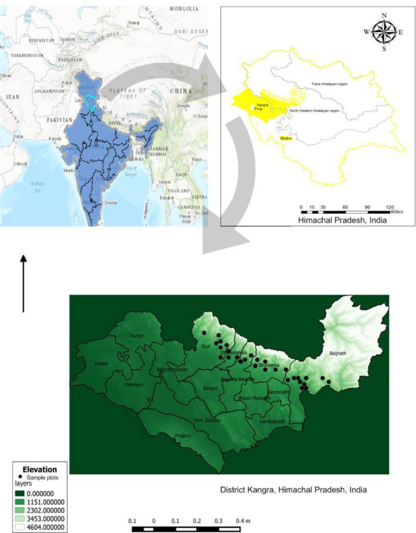

Fig. 1. . Location of the present study area in the Indian Himalayas.

The study area endows with rich faunal and avifaunal diversity, including musk [deer](https://www.sciencedirect.com/topics/agricultural-and-biological-sciences/cervidae), leopard, Himalayan tahr, Himalayan black bear, goral, blue sheep, western tragopan, Himalayan monal, snow partridge, koklass and white crested kalij (Sharma, 2017). The maximum mean temperature in the study area varies from 18.32 °C to 30.8 °C and the minimum mean temperature ranges from 1.23 °C to 29.2 °C. The annual rainfall ranges from 147.37 to 228.43 mm (Sharma, 2017). The soils in district are shallow black, brown and alluvial. The major portion of the district falls within the drainage basin of Beas where soils are alluvial silty loam with high fertility status (Department of Agriculture, 2009). The human population in Kangra district is 1507,223, which is highest among all districts of Himachal Pradesh. Animal husbandry, agriculture, horticulture and collection of non-timber forest produce are the major occupations of the local people.

### 2.2. Forest stratification and sampling

To study the patterns in species diversity along the altitudinal gradient, the study area was divided into three zones based on the altitude and forest types, such as, subtropical forests (1000–1500 m), [temperate forests](https://www.sciencedirect.com/topics/agricultural-and-biological-sciences/temperate-forest) (1501–3000 m) and subalpine forests (>3000 m) following Champion and Seth (1968). Nested plot method was employed for sampling trees, shrubs and herbs following Misra (1968). The quadrats of 10 × 10 m for trees, 5 × 5 m for shrubs and 1 × 1 m for herbs were laid down in each zone. A total of 1106 sampling plots were laid along the altitudinal gradients. [Plant species](https://www.sciencedirect.com/topics/earth-and-planetary-sciences/plant-specie) with their individuals were enumerated in each quadrat. The communities were identified based on the dominance of woody species in particular localities.

### 2.3. Quantitative analysis

The Shannon-Weiner diversity index (Shannon and Weaver, 1949) has been used by most of the researchers in the past for measuring plant species diversity in the North-West Himalayas. The Shannon-Weiner diversity index, therefore, was used for calculation of plant species diversity as per the following formula:$H'=−∑pilogpi$

- •

  Where, H´ = Shannon-Weiner diversity index
- •

  pi = the proportion of individuals of i<sup>th</sup> species

Since there are number of studies available on the plant species diversity in the North-West Himalayas and most of them have used the Shannon-Weiner diversity index, the use and application of the same index further helps in drawing comparison in plant species diversity of the present study area with other similar localities in the North-West Himalayas.

## 3. Results

A total of 184 plant species were sampled during the present investigations in the study area. These species were distributed over 165 genera and 78 families, of which 154 genera representing 71 families belonged to [Angiosperm](https://www.sciencedirect.com/topics/agricultural-and-biological-sciences/angiosperm), 7 genera representing 3 families belonged to [Gymnosperms](https://www.sciencedirect.com/topics/agricultural-and-biological-sciences/gymnosperm) and 4 genera with 4 families belonged to [Pteridophytes](https://www.sciencedirect.com/topics/agricultural-and-biological-sciences/pteridophyte). Of the total species, 41 were tree species, 29 shrub species, 91 herbaceous species, 7 [ferns](https://www.sciencedirect.com/topics/agricultural-and-biological-sciences/fern-ally) and rest of the 16 species were comprised of climbers, [epiphytes](https://www.sciencedirect.com/topics/agricultural-and-biological-sciences/epiphyte), and grasses (Table 1). The highest number of plant species (116 species including 25 tree species, 13 shrub species and 78 herbaceous species) was recorded in the [temperate forests](https://www.sciencedirect.com/topics/agricultural-and-biological-sciences/temperate-forest), followed by sub-tropical forests (68 species including 21 tree species, 12 shrub species and 35 herbaceous species) and sub-alpine forests (51 species including 8 tree species, 7 shrub species and 36 herbaceous species). The temperate forests were the center of woody plant species richness and species diversity as the highest percentage of woody plant species (both trees and shrubs) was found in the temperate forests (60% trees and 45% shrubs), followed by sub-tropical (50% trees and 41% shrubs) and sub-alpine forests (19% trees and 24% shrubs).

Table 1. Taxonomical distribution of plant species in the study area.

| Taxonomic group | Family | Genera | Species | Herbs | Shrub | Tree | Ferns | Grasses | Others |
| --- | --- | --- | --- | --- | --- | --- | --- | --- | --- |
| Angiosperms | 71 | 154 | 168 | 91 | 28 | 34 | - | 6 | 10 |
| Gymnosperms | 3 | 7 | 9 | - | 1 | 7 | - | - | - |
| Pteridophytes | 4 | 4 | 7 | - | - | - | 7 | - | - |
| Empty Cell | 78 | 165 | 184 | 91 | 29 | 41 | 7 | 6 | 10 |

Along the altitudinal gradient in the study area a total of 10 forest community types were identified, of which the highest number of forest community was found in the temperate forests. Of the 6 forest community types in the temperate forests, four of them were dominated by *[Quercus](https://www.sciencedirect.com/topics/agricultural-and-biological-sciences/quercus)* spp. (either by *Quercus leucotrichophora* or by *Quercus semecarpifolia*). *[Cedrus deodara](https://www.sciencedirect.com/topics/agricultural-and-biological-sciences/cedrus-deodara)**,* *[Rhododendron arboreum](https://www.sciencedirect.com/topics/agricultural-and-biological-sciences/rhododendron-arboreum)**,* and *Acer* sp. were the major associate tree species of *Quercus leucotrichophora* community whereas *Abies pindrow* was the major associate tree species in *Quercus semecarpifolia* community.

The species diversity of woody plant species (tree and shrub) was higher in the temperate forests in comparison to sub-tropical and sub-alpine forests. Three forest communities such as *[Pinus roxburghii](https://www.sciencedirect.com/topics/agricultural-and-biological-sciences/pinus-roxburghii)**,* *[Pinus wallichiana](https://www.sciencedirect.com/topics/agricultural-and-biological-sciences/pinus-wallichiana)* and *Quercus semecarpifolia* were predominated by single tree species hence they mainly formed pure stands. *Pinus roxburghii* community was found in the sub-tropical forest whereas the rest two single tree dominated communities namely *Pinus wallichiana* and *Quercus semecarpifolia* were located in the temperate forests (Photographs 1–4).

Photo 1, Photo 2, Photo 3, Photo 4

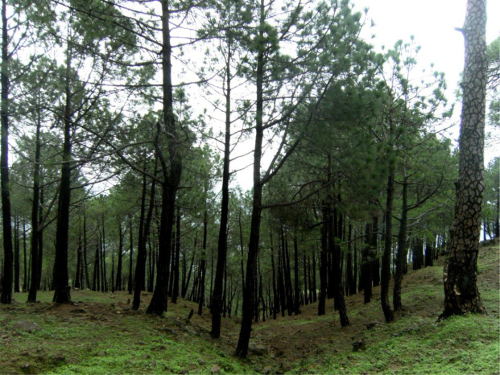

Photo 1. . Sub-tropical forests in the study area dominated by chir [pine](https://www.sciencedirect.com/topics/agricultural-and-biological-sciences/pinus).

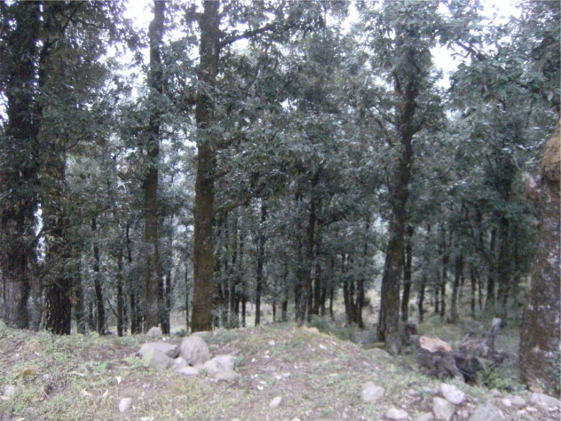

Photo 2. . Temperate forests in the study area dominated by [oak](https://www.sciencedirect.com/topics/agricultural-and-biological-sciences/quercus).

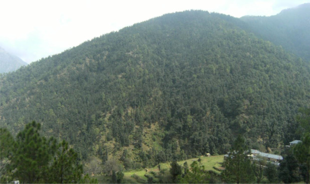

Photo 3. . Temperate mixed forests in the study area.

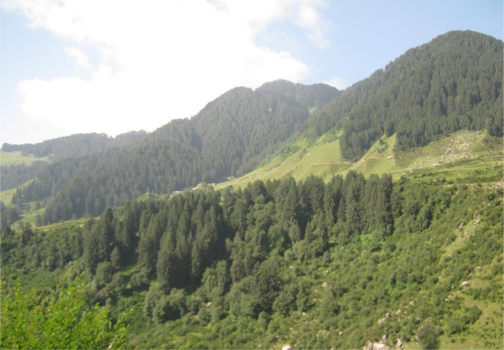

Photo 4. . Sub-alpine forests in the study area.

Among all the forest communities along the altitudinal gradient, the tree species diversity was highest in the *Picea smithiana - Cedrus deodara - Abies pindrow - Pinus wallichiana* community (H’=2.84), followed by *Quercus leucotrichophora - Acer* sp. - *[Taxus wallichiana](https://www.sciencedirect.com/topics/agricultural-and-biological-sciences/taxus-wallichiana)* *- Betula utilis* community (H’=2.78), and *Quercus semecarpifolia* community (H’=2.69). Among the pure tree stands community *Quercus semecarpifolia* community was richest in species diversity, followed by *Pinus wallichiana* community (Table 2). The lowest tree species diversity was found in the *Pinus roxburghii* community in the sub-tropical forests (H’=2.01) and *Betula utilis - Picea smithiana - Rhododendron campanulatum* community in the sub-alpine forests (H’=2.04).

Table 2. Plant species diversity across the forest types along the altitudinal gradient in Dhauladhar mountain range of the North-West Himalaya.

| Forest Type | Community | Species diversity (H’) |  |  |
| --- | --- | --- | --- | --- |
|  |  | Tree | Shrub | Herb |
| Sub-tropical (1000–1500 m) | *Pinus roxburghii* | 2.01 | 2.00 | 2.09 |
|  | Mixed sub-tropical forest | 2.11 | 2.12 | 2.13 |
| Temperate (1501–3000 m) | *Quercus leucotrichophora - Cedrus deodara - Rhododendron arboreum* | 2.63 | 2.15 | 2.36 |
|  | *Quercus leucotrichophora - Acer* sp - *Taxus wallichiana - Betula utilis* | 2.78 | 2.19 | 2.65 |
|  | *Quercus semecarpifolia - Abis pindrow* | 2.59 | 2.31 | 2.45 |
|  | *Pinus wallichiana* | 2.21 | 2.28 | 2.01 |
|  | *Picea smithiana - Cedrus deodara - Abies pindrow - Pinus wallichiana* | 2.84 | 2.46 | 2.78 |
|  | *Quercus semecarpifolia* | 2.69 | 2.31 | 2.21 |
| Subalpine (>3000 m) | *Abies pindrow - Quercus floribunda* | 2.15 | 2.07 | 2.34 |
|  | *Betula utilis - Picea smithiana - Rhododendron campanulatum* | 2.04 | 2.09 | 3.01 |

The species diversity of shrub species also varied along the altitudinal gradient across the forest communities (H’=2.00–2.46). Likewise, the tree species diversity, the highest shrub diversity (H’=2.46) was found in *Picea smithiana - Cedrus deodara - Abies pindrow - Pinus wallichiana* community, followed by *Quercus semecarpifolia* community and *Quercus semecarpifolia -* *Abies pindrow* community (H’=2.31). The species diversity of herbaceous species was lowest in *Pinus roxburghii* (H’=2.09) and *Pinus wallichiana* (H’=2.01) forest communities. The highest species diversity of herbs was estimated for *Betula utilis - Picea smithiana - Rhododendron campanulatum* forest community in the sub-alpine forests (H’=3.01).

## 4. Discussion

The present study reveals that the elevation is one of the major factors in the Himalayan mountains, which determines the establishment and existence of various forest communities and species diversity. Similar observations are made for the mountainous region, elsewhere, that the elevation as a regional environmental factor best predicts the diversity and distribution of woody species (Bacaro et al., 2008). Along an altitudinal gradient there was a hump-shaped curve in the species diversity of woody plant species whereas the species diversity of herbaceous species increased with elevations from sub-tropical to sub-alpine forests in the present study area.

Studies conducted elsewhere in various parts of the North-West Himalaya in India indicate wide range in tree species diversity (H’=0.45–3.37) across various localities within temperate forests. The lowest tree species diversity (H’=0.45) is reported from Khirsu region of Pauri Garhwal district of Uttarakhand state (Sharma et al., 2010), whereas the highest tree species diversity (H’=3.37) is reported from the Kedarnath [Wildlife Sanctuary](https://www.sciencedirect.com/topics/earth-and-planetary-sciences/wildlife-sanctuary) in Chamoli district of Uttarakhand (Bhat et al., 2020). In sub-alpine forests, the tree species diversity varies from H’=0.17 in Anantnag district of Jammu and Kashmir (Dar and Sundarapandian, 2016) to H’=2.29 in Kedarnath Wildlife Sanctuary (Bhat et al., 2020). Generally, the human access and anthropogenic disturbances remain marginal in the sub-alpine forests but the environmental stresses stay high, which subsequently result in the low species diversity of woody plant species. Though the range of species diversity varies in other parts of the North-West Himalaya, the general pattern in species diversity remains almost similar along the elevations (Table 3).

Table 3. Comparison of tree species diversity in the present study area with the studies conducted elsewhere within the North-West Himalaya.

| Locality | Altitude (m) | Species diversity (H’) |  |  | Reference |  |
| --- | --- | --- | --- | --- | --- | --- |
|  |  | Sub-tropical (1000–1500 m) | Temperate (1501–3000 m) | Sub-alpine (>3000 m) |  |  |
| Kangra, Himachal Pradesh | 1000->3000 | 2.01–2.11 | 2.21–2.84 | 2.04–2.15 |  | Present study |
| Uttarkashi, Tehri, Pauri | 2010–2565 | – | 1.27–1.86 | – | Singh et al. (2016) |  |
| Chaurangikhal Garhwal | 1850–2800 | – | 0.99–2.37 | – | Sharma et al. (2009) |  |
| Mandal-Chopta, Chamoli Garhwal | 1500–2500 | – | 2.43–3.33 | – | Gairola et al. (2011) |  |
| Kedarnath Wildlife Sanctuary | 1550–3100 | – | 2.29–3.37 | 2.09–2.29 | Bhat et al. (2020) |  |
| Bhyundar valley, Chamoli | 2550–3600 | – | 2.48 | 1.48–1.62 | Kala (2004) |  |
| Dudhatoli, Pauri Garhwal | 2300–2600 | – | 1.20 | – | Sharma et al. (2010) |  |
| Buvakhal, Khirshu, Pauri Garhwal | 1600–2100 | – | 0.45 | – | Sharma et al. (2010) |  |
| Fatehpur, Deogadd | 750–1250 | 1.14 | – | – | Sharma et al. (2010) |  |
| Phakot, Tehri Garhwal | 600–1900 | 2.41–2.44 | 1.16–1.44 | – | Pokhriyal et al. (2012) |  |
| Hamta pass, Himachal Pradesh | 3057–3760 | – | – | 0.40–0.90 | Dasila et al. (2021) |  |
| Anantnag, Jammu and Kashmir | 2200–2400 | – | 1.06 | – | Dar and Sundarapandian (2016) |  |
| Anantnag, Jammu and Kashmir | 2800–3250 | – | – | 0.17 | Dar and Sundarapandian (2016) |  |
| Tirthan valley, Himachal Pradesh | 1500–3000 | – | 1.95–2.59 | – | Mohapatra et al. (2020) |  |
| Ropa-Giavung, Kinnaur, Himachal Pradesh | 3000–3500 | – | – | 2.01 | Verma and Kapoor (2011) |  |
| Khokhan Wildlife Sanctuary, Kullu, Himachal Pradesh | 1640–2400 | – | 0.74–2.66 | – | Pant and Samant (2012) |  |

There are two prominent patterns in tree species diversity across various forests types along the elevations in the Himalayas. Either there is a hump-shaped curve in the species diversity or there is a continuous decline in tree species diversity along the altitudinal gradients. Within temperate forests, continuous decline is reported in the tree species diversity along the elevation from 2250 m to 2800 m (Sharma et al., 2009). The [Forest Survey](https://www.sciencedirect.com/topics/agricultural-and-biological-sciences/forest-surveys) of India's (2019) study on the tree species diversity of Himachal Pradesh reports highest tree species diversity to the Himalayan moist temperate forests (H’=2.95), followed by subtropical [pine](https://www.sciencedirect.com/topics/agricultural-and-biological-sciences/pinus) forests (H’=2.63), Himalayan dry temperate forests (H’=2.03), and sub-alpine forests (H’=1.64; FSI, 2019). Further, the shrub species diversity is also reported highest in the Himalayan moist temperate forests (H’=3.25), followed by Himalayan dry temperate forests (H’=2.56), subtropical pine forests (H’=2.17), and lowest in the sub-alpine forests (H’=1.83; FSI, 2019).

Generally, the temperate forests remain the center of high tree species diversity along the elevations from sub-tropical to sub-alpine forests however there are possibilities of locality-specific variations in species diversity due to microclimatic conditions, [landforms](https://www.sciencedirect.com/topics/agricultural-and-biological-sciences/landform), [soil properties](https://www.sciencedirect.com/topics/agricultural-and-biological-sciences/soil-properties) and level of anthropogenic disturbances (Shrestha et al., 1999; Dar and Sundarapandian, 2016; Bhatt et al., 2020). A study conducted in Phakot watershed of Tehri Garhwal of Uttarakhand (Pokhriyal et al., 2012) reports higher tree species diversity in sub-tropical forests (H’=2.41–2.44) than the temperate forests (H’=1.16–1.44). Relatively low species diversity in sub-tropical forests in the present study area may be due to number of causes including heavy anthropogenic pressures and invasion of [Lantana](https://www.sciencedirect.com/topics/agricultural-and-biological-sciences/lantana) camera (Sharma and Kala, 2018). The predominance of *[Pinus roxburghii](https://www.sciencedirect.com/topics/agricultural-and-biological-sciences/pinus-roxburghii)* is also considered the cause of low species diversity in the sub-tropical forests (Sharma et al., 2010).

## Declaration of Competing Interest

Authors declare that they have no conflict of interest.

## Acknowledgements

The authors thank local people of Dhauladhar mountain range in Kangra district and state forest department of Himachal Pradesh for their support during the field work. The authors extend thanks to the Director, Indian Institute of Forest Management Bhopal. The editors and two anonymous reviewers are acknowledged for their constructive suggestions for improving the manuscript.

## Funding information

This research did not receive any specific grant from funding agencies in the public, commercial and not for profit sector.

## References

1. Aguilar-Santelises and del Castillo, 2013

   R. Aguilar-Santelises, R.F. del Castillo

   Factors affecting woody plant species diversity of fragmented seasonally dry oak forests in the Mixteca Alta

   Oaxaca, Mexico. Revista Mexicana de Biodiversidad, 84 (2) (2013), pp. 575-590

   [View PDF](https://www.sciencedirect.com/science/article/pii/S1870345313728768/pdfft?md5=f6f9534589d7c9cdc5b17e92f791227e&pid=1-s2.0-S1870345313728768-main.pdf)[View article](https://www.sciencedirect.com/science/article/pii/S1870345313728768)[CrossRef](https://doi.org/10.7550/rmb.30458)[View in Scopus](https://www.scopus.com/inward/record.url?eid=2-s2.0-84883591763&partnerID=10&rel=R3.0.0)Google Scholar
2. Antonelli et al., 2018

   A. Antonelli, W.D. Kissling, S.G.A. Flantua, M.A. Bermúdez, A. Mulch, A.N. Muellner-Riehl, H. Kreft, H.P. Linder, C. Badgley, J. Fjeldså, S.A. Fritz, C. Rahbek, F. Herman, H. Hooghiemstra, C. Hoornet

   Geological and climatic influences on mountain biodiversity

   Nat. Geosci., 11 (2018), pp. 718-725, 10.1038/s41561-018-0236-z

   [View in Scopus](https://www.scopus.com/inward/record.url?eid=2-s2.0-85054129319&partnerID=10&rel=R3.0.0)Google Scholar
3. Bacaro et al., 2008

   G. Bacaro, D. Rocchini, I. Bonini, M. Marignani, S. Maccherini, A. Chiarucci

   The role of regional and local scale predictors for plant species richness in Mediterranean forests

   Plant Biosyst., 142 (2008), pp. 630-642

   [CrossRef](https://doi.org/10.1080/11263500802411064)[View in Scopus](https://www.scopus.com/inward/record.url?eid=2-s2.0-56649103917&partnerID=10&rel=R3.0.0)Google Scholar
4. Badola et al., 2015

   R. Badola, S.A. Hussain, P. Dobriyal, S. Barthwal

   Assessing the effectiveness of policies in sustaining and promoting ecosystem services in the Indian Himalayas. International Journal of Biodiversity Science

   Ecosyst. Serv. Manage., 11 (3) (2015), pp. 216-224

   [CrossRef](https://doi.org/10.1080/21513732.2015.1030694)[View in Scopus](https://www.scopus.com/inward/record.url?eid=2-s2.0-84939263636&partnerID=10&rel=R3.0.0)Google Scholar
5. Bawa, Joseph and Setty, 2007

   K.S. Bawa, G. Joseph, S. Setty

   Poverty, biodiversity and institutions in forest-agriculture ecotones in the Western Ghats and Eastern Himalaya ranges of India

   Agric. Ecosyst. Environ., 121 (3) (2007), pp. 287-295

   [View PDF](https://www.sciencedirect.com/science/article/pii/S0167880906004518/pdfft?md5=769fab022e49a4f42dbf1b5b2bbf961f&pid=1-s2.0-S0167880906004518-main.pdf)[View article](https://www.sciencedirect.com/science/article/pii/S0167880906004518)[View in Scopus](https://www.scopus.com/inward/record.url?eid=2-s2.0-33947172388&partnerID=10&rel=R3.0.0)Google Scholar
6. Bhat et al., 2020

   J.A. Bhat, M. Kumar, A.K. Negi, N.P. Todaria, Z.A. Malik, N.A. Pala, A. Kumar, G. Shukla

   Species diversity of woody vegetation along altitudinal gradient of the Western Himalayas

   Global Ecol. Conserv., 24 (2020), p. e01302, 10.1016/j.gecco.2020.e01302

   [View PDF](https://www.sciencedirect.com/science/article/pii/S235198942030843X/pdfft?md5=21685ddd4a1104a221e845fb006cd796&pid=1-s2.0-S235198942030843X-main.pdf)[View article](https://www.sciencedirect.com/science/article/pii/S235198942030843X)[View in Scopus](https://www.scopus.com/inward/record.url?eid=2-s2.0-85092345952&partnerID=10&rel=R3.0.0)Google Scholar
7. Bhatt, Negi and Rawal, 2020

   I.D. Bhatt, V.S. Negi, R.S. Rawal

   Promoting Nature-Based Solution (NbS) Through Restoration of Degraded Landscapes in the Indian Himalayan Region. In: Nature-based Solutions For Resilient Ecosystems and Societies

   Springer, Singapore (2020), pp. 197-211

   pp

   [CrossRef](https://doi.org/10.1007/978-981-15-4712-6_12)Google Scholar
8. Champion and Seth, 1968

   H.G. Champion, S.K Seth

   A Revised Survey of the Forest Types of India

   Government of India Publications, India (1968)

   [Google Scholar](https://scholar.google.com/scholar_lookup?title=A%20Revised%20Survey%20of%20the%20Forest%20Types%20of%20India&publication_year=1968&author=H.G.%20Champion&author=S.K%20Seth)
9. Clarke and Gaston, 2006

   A. Clarke, K.J Gaston

   Climate, energy and diversity

   Proc. R. Soc. B: Biol. Sci., 273 (2006), pp. 2257-2266

   [CrossRef](https://doi.org/10.1098/rspb.2006.3545)[View in Scopus](https://www.scopus.com/inward/record.url?eid=2-s2.0-33748689735&partnerID=10&rel=R3.0.0)[Google Scholar](https://scholar.google.com/scholar_lookup?title=Climate%2C%20energy%20and%20diversity&publication_year=2006&author=A.%20Clarke&author=K.J%20Gaston)
10. Dar and Sundarapandian, 2016

    J.A. Dar, S. Sundarapandian

    Patterns of plant diversity in seven temperate forest types of Western Himalaya

    India. J. Asia-Pacific Biodiversity, 9 (3) (2016), pp. 280-292

    [View PDF](https://www.sciencedirect.com/science/article/pii/S2287884X16300279/pdfft?md5=0b7e6a62c81dd6ea6088b21e3b209f68&pid=1-s2.0-S2287884X16300279-main.pdf)[View article](https://www.sciencedirect.com/science/article/pii/S2287884X16300279)[View in Scopus](https://www.scopus.com/inward/record.url?eid=2-s2.0-84990062884&partnerID=10&rel=R3.0.0)Google Scholar
11. Dasila, Samant and Pandey, 2021

    K. Dasila, S.S. Samant, A. Pandey

    Studies on subalpine forests of Hamta Pass area in Himachal Pradesh, India with a focus on Betula utilis populations

    Curr. Sci., 120 (5) (2021), pp. 872-882

    [CrossRef](https://doi.org/10.18520/cs/v120/i5/872-882)[View in Scopus](https://www.scopus.com/inward/record.url?eid=2-s2.0-85104699453&partnerID=10&rel=R3.0.0)Google Scholar
12. Department of Agriculture 2009

    Department of Agriculture

    District Agriculture Plan Kangra Himachal Pradesh Volume-IV

    Department of Agriculture, Himachal Pradesh. Consulting Agency CSK Himachal Pradesh Agricultural University, Palampur (2009)

    [Google Scholar](https://scholar.google.com/scholar_lookup?title=District%20Agriculture%20Plan%20Kangra%20Himachal%20Pradesh%20Volume-IV&publication_year=2009&author=Department%20of%20Agriculture)
13. Fedor and Zvaríková, 2019

    P. Fedor, M. Zvaríková

    Biodiversity Indices. In: Encyclopedia of Ecology

    Elsevier, Amsterdam, Netherlands (2019), pp. 337-346

    (Editor: Farth, B.)

    [View PDF](https://www.sciencedirect.com/science/article/pii/B9780124095489105585/pdfft?md5=8bec912ffcf7ab06c10975839a9cd3ed&pid=3-s2.0-B9780124095489105585-main.pdf)[View article](https://www.sciencedirect.com/science/article/pii/B9780124095489105585)[Google Scholar](https://scholar.google.com/scholar_lookup?title=Biodiversity%20Indices.%20In%3A%20Encyclopedia%20of%20Ecology&publication_year=2019&author=P.%20Fedor&author=M.%20Zvar%C3%ADkov%C3%A1)
14. FSI 2019

    FSI

    India State of Forest Report 2019

    Forest Survey of India, Dehradun, India (2019)

    [Google Scholar](https://scholar.google.com/scholar_lookup?title=India%20State%20of%20Forest%20Report%202019&publication_year=2019&author=FSI)
15. Gairola et al., 2011

    S. Gairola, C.M. Sharma, S. Suyal, S.K. Ghildiya

    Species composition and diversity in mid-altitudinal moist temperate forests of the Western Himalaya

    J. Forest Sci., 27 (1) (2011), pp. 1-15

    Google Scholar
16. Gaston, 2000

    D.J. Gaston

    Global patterns in biodiversity

    Nature, 405 (2000), pp. 220-227

    [View in Scopus](https://www.scopus.com/inward/record.url?eid=2-s2.0-0034636581&partnerID=10&rel=R3.0.0)[Google Scholar](https://scholar.google.com/scholar_lookup?title=Global%20patterns%20in%20biodiversity&publication_year=2000&author=D.J.%20Gaston)
17. Giorgini et al., 2015

    D. Giorgini, P. Giordani, G. Casazza, V. Amici, M.G. Mariotti, A. Chiarucci

    Woody species diversity as predictor of vascular plant species diversity in forest ecosystems

    Forest Ecol. Manag., 345 (2015), pp. 50-55

    [View PDF](https://www.sciencedirect.com/science/article/pii/S0378112715000742/pdfft?md5=ff83c4e0ff95033751fd8299a4b87843&pid=1-s2.0-S0378112715000742-main.pdf)[View article](https://www.sciencedirect.com/science/article/pii/S0378112715000742)[View in Scopus](https://www.scopus.com/inward/record.url?eid=2-s2.0-84924274181&partnerID=10&rel=R3.0.0)Google Scholar
18. Kala, 1998

    C.P. Kala

    Ecology and Conservation of Alpine Meadows in the Valley of Flowers National Park, Garhwal Himalaya. Ph.D. Thesis

    Forest Research Institute, Dehradun (1998)

    Google Scholar
19. Kala, 2004

    C.P. Kala

    The Valley of Flowers: Myth and Reality

    International Book Distributors, Dehradun, India (2004)

    [Google Scholar](https://scholar.google.com/scholar_lookup?title=The%20Valley%20of%20Flowers%3A%20Myth%20and%20Reality&publication_year=2004&author=C.P.%20Kala)
20. Kala, 2014

    C.P. Kala

    Deluge, disaster and development in Uttarakhand Himalayan region of India: challenges and lessons for disaster management

    Int. J. Disaster Risk Reduc., 8 (2014), pp. 143-152

    [View PDF](https://www.sciencedirect.com/science/article/pii/S2212420914000235/pdfft?md5=8756edfecc65488343d48a172ff3d0ca&pid=1-s2.0-S2212420914000235-main.pdf)[View article](https://www.sciencedirect.com/science/article/pii/S2212420914000235)[View in Scopus](https://www.scopus.com/inward/record.url?eid=2-s2.0-84898613209&partnerID=10&rel=R3.0.0)Google Scholar
21. Kala, 2015a

    Editors

    C.P. Kala

    Medicinal and aromatic plants of Uttarakhand: an ecosystem service for human wellbeing

    V.K. Dhaundiyal, M. Sundriyal (Eds.), In: Ecosystem Services and Its Mainstreaming in Development Planning Process, Uttarakhand Science Education and Research Centre (USERC), & Bishen Singh Mahendra Pal Singh, Dehradun, India (2015), pp. 140-149

    Editorspp

    [View in Scopus](https://www.scopus.com/inward/record.url?eid=2-s2.0-85144255332&partnerID=10&rel=R3.0.0)[Google Scholar](https://scholar.google.com/scholar_lookup?title=Medicinal%20and%20aromatic%20plants%20of%20Uttarakhand%3A%20an%20ecosystem%20service%20for%20human%20wellbeing&publication_year=2015&author=C.P.%20Kala)
22. Kala, 2015b

    C.P. Kala

    Forest structure and anthropogenic pressures in the Pachmarhi Biosphere Reserve of India

    J. Forestry Res., 26 (4) (2015), pp. 867-874

    [CrossRef](https://doi.org/10.1007/s11676-015-0083-3)[View in Scopus](https://www.scopus.com/inward/record.url?eid=2-s2.0-84945439260&partnerID=10&rel=R3.0.0)[Google Scholar](https://scholar.google.com/scholar_lookup?title=Forest%20structure%20and%20anthropogenic%20pressures%20in%20the%20Pachmarhi%20Biosphere%20Reserve%20of%20India&publication_year=2015&author=C.P.%20Kala)
23. Khan et al., 2012

    S.M. Khan, S. Page, H. Ahmad, H. Shaheen, D. Harper

    Vegetation dynamics in the Western Himalayas, diversity indices and climate change

    Sci. Technol. Dev., 31 (3) (2012), pp. 232-243

    Google Scholar
24. Majila and Kala, 2010

    B.S. Majila, C.P. Kala

    Forest structure and regeneration along the altitudinal gradient in the Binsar Wildlife Sanctuary, Uttarakhand Himalaya

    India. Russian J. Ecol., 41 (1) (2010), pp. 75-83

    [View in Scopus](https://www.scopus.com/inward/record.url?eid=2-s2.0-75949088543&partnerID=10&rel=R3.0.0)Google Scholar
25. Mani, 1974

    M.S. Mani

    Fundamental of High Attitude Biology

    Oxford and IBH Publications (1974), p. 196

    [Google Scholar](https://scholar.google.com/scholar_lookup?title=Fundamental%20of%20High%20Attitude%20Biology&publication_year=1974&author=M.S.%20Mani)
26. Mani, 1978

    M.S. Mani

    Ecology and Phytogeography of the High Altitude Plants of the Northwest Himalaya: Introduction to High Altitude Botany

    Halstead Press, Ultimo, Australia (1978), p. 205

    p

    Google Scholar
27. Misra, 1968

    R. Misra

    Ecology Workbook

    Oxford and IBH Publishing Company, Calcutta. India (1968)

    [Google Scholar](https://scholar.google.com/scholar_lookup?title=Ecology%20Workbook&publication_year=1968&author=R.%20Misra)
28. Mohapatra et al., 2020

    S.R. Mohapatra, H.P. Sankhyan, S. Thakur, S.B. Naik, K. Samantara

    Altitudinal variation of woody vegetation in Tirthan valley of Great Himalayan National Park at Kullu, Himachal Pradesh

    Int. J. Chem. Stud., 8 (1) (2020), pp. 1282-1288

    [CrossRef](https://doi.org/10.22271/chemi.2020.v8.i1r.8433)Google Scholar
29. Pant and Samant, 2012

    S. Pant, S.S. Samant

    Diversity and regeneration status of tree species in Khokhan Wildlife Sanctuary, North-western Himalaya

    Trop. Ecol., 53 (3) (2012), pp. 317-331

    [View in Scopus](https://www.scopus.com/inward/record.url?eid=2-s2.0-84862569332&partnerID=10&rel=R3.0.0)Google Scholar
30. Pokhriyal, Chauhan and Todaria, 2012

    P. Pokhriyal, D.S. Chauhan, N.P. Todaria

    Effect of altitude and disturbance on structure and species diversity of forest vegetation in a watershed of central Himalaya

    Trop. Ecol., 53 (3) (2012), pp. 307-315

    [View in Scopus](https://www.scopus.com/inward/record.url?eid=2-s2.0-84862518898&partnerID=10&rel=R3.0.0)Google Scholar
31. Qian and Kissling, 2010

    H. Qian, W.D. Kissling

    Spatial scale and cross-taxon congruence of terrestrial vertebrate and vascular plant species richness in China

    Ecology, 91 (2010), pp. 1172-1183

    [CrossRef](https://doi.org/10.1890/09-0620.1)[View in Scopus](https://www.scopus.com/inward/record.url?eid=2-s2.0-77951193559&partnerID=10&rel=R3.0.0)Google Scholar
32. Rawal and Dhar, 1997

    R.S. Rawal, U. Dhar

    Sensitivity of timberline flora in Kumaun Himalaya, India: conservation implications

    Arct. Alp. Res., 29 (1) (1997), pp. 112-121

    [CrossRef](https://doi.org/10.2307/1551841)[View in Scopus](https://www.scopus.com/inward/record.url?eid=2-s2.0-0030609772&partnerID=10&rel=R3.0.0)Google Scholar
33. Shannon and Weaver, 1949

    C.E. Shannon, W. Weaver

    The Mathematical Theory of Communicalion

    University Illinois Press, Urbana, Ill (1949), p. 117

    pp

    [Google Scholar](https://scholar.google.com/scholar_lookup?title=The%20Mathematical%20Theory%20of%20Communicalion&publication_year=1949&author=C.E.%20Shannon&author=W.%20Weaver)
34. Sharma et al., 2010

    C.M. Sharma, N.P. Baduni, S. Gairola, S.K. Ghildiyal, S. Suyal

    Tree diversity and carbon stocks of some major forest types of Garhwal Himalaya

    India. Forest Ecol. Manage., 260 (12) (2010), pp. 2170-2179

    [View PDF](https://www.sciencedirect.com/science/article/pii/S0378112710005463/pdfft?md5=798338bc0a69ae435c36586e06238f98&pid=1-s2.0-S0378112710005463-main.pdf)[View article](https://www.sciencedirect.com/science/article/pii/S0378112710005463)[View in Scopus](https://www.scopus.com/inward/record.url?eid=2-s2.0-78049314002&partnerID=10&rel=R3.0.0)Google Scholar
35. Sharma et al., 2009

    C.M. Sharma, S. Suyal, S. Gairola, S.K. Ghildiyal

    Species richness and diversity along an altitudinal gradient in moist temperate forest of Garhwal Himalaya

    J. Am. Sci., 5 (5) (2009), pp. 119-128

    [CrossRef](https://doi.org/10.1001/archoto.2008.546)Google Scholar
36. Sharma, 2017

    N. Sharma

    Conservation and Utilization of Medicinal and Aromatic Plants in Dhauladhar mountain Range of Himachal Pradesh

    Forest Research Institute (Deemed University, Dehradun, India (2017)

    Ph.D. Thesis

    Google Scholar
37. Sharma and Kala, 2018

    N. Sharma, C.P. Kala

    Patterns in distribution, population density and uses of medicinal plants along the altitudinal gradient in Dhauladhar mountain range of Indian Himalayas

    Curr. Sci., 114 (11) (2018), pp. 2323-2328

    [CrossRef](https://doi.org/10.18520/cs/v114/i11/2323-2328)[View in Scopus](https://www.scopus.com/inward/record.url?eid=2-s2.0-85048224535&partnerID=10&rel=R3.0.0)Google Scholar
38. Sharma and Kala, 2022

    N. Sharma, C.P. Kala

    Harvesting patterns, risk of harvesting and sustainability of medicinal and aromatic plants in Kangra district of Himachal Pradesh in India

    J. Appl. Res. Med. Aromatic Plants, 26 (2022), 10.1016/j.jarmap.2021.100367

    Google Scholar
39. Singh et al., 1996

    In

    D.K. Singh, P.K. Hajra, G.S. Gujral, V. Sharma

    Floristic diversity

    editors

    Changing Perspectives of Biodiversity Status in the Himalaya. New Delhi: British Council Division, British High Commission (1996), pp. 23-38

    pp

    [View in Scopus](https://www.scopus.com/inward/record.url?eid=2-s2.0-85103371199&partnerID=10&rel=R3.0.0)[Google Scholar](https://scholar.google.com/scholar_lookup?title=Floristic%20diversity&publication_year=1996&author=D.K.%20Singh&author=P.K.%20Hajra&author=G.S.%20Gujral&author=V.%20Sharma)
40. Singh, Malik and Sharma, 2016

    S. Singh, Z.A. Malik, C.M. Sharma

    Tree species richness, diversity, and regeneration status in different oak (Quercus spp.) dominated forests of Garhwal Himalaya Indian

    J. Asia Pacific Biodiv., 9 (2016), pp. 293-300

    [View PDF](https://www.sciencedirect.com/science/article/pii/S2287884X16300528/pdfft?md5=fa9d60d4c17fdf22f9f61e8ec38f523c&pid=1-s2.0-S2287884X16300528-main.pdf)[View article](https://www.sciencedirect.com/science/article/pii/S2287884X16300528)[View in Scopus](https://www.scopus.com/inward/record.url?eid=2-s2.0-84990055891&partnerID=10&rel=R3.0.0)[Google Scholar](https://scholar.google.com/scholar?q=Tree%20species%20richness,%20diversity,%20and%20regeneration%20status%20in%20different%20oak%20%20dominated%20forests%20of%20Garhwal%20Himalaya%20Indian)
41. Thapa and Chapman, 2010

    S. Thapa, D.S. Chapman

    Impacts of resource extraction on forest structure and diversity in Bardia National Park

    Nepal. Forest Ecol. Manage., 259 (3) (2010), pp. 641-649

    [View PDF](https://www.sciencedirect.com/science/article/pii/S0378112709008548/pdfft?md5=08485439845bf635c1f23f417aae3d8c&pid=1-s2.0-S0378112709008548-main.pdf)[View article](https://www.sciencedirect.com/science/article/pii/S0378112709008548)[View in Scopus](https://www.scopus.com/inward/record.url?eid=2-s2.0-73049108064&partnerID=10&rel=R3.0.0)Google Scholar
42. Verma, 2008

    M. Verma

    Framework for forest resource accounting: factoring in the intangibles

    Int. Forestry Rev., 10 (2) (2008), pp. 362-375

    [CrossRef](https://doi.org/10.1505/ifor.10.2.362)[View in Scopus](https://www.scopus.com/inward/record.url?eid=2-s2.0-67649229015&partnerID=10&rel=R3.0.0)[Google Scholar](https://scholar.google.com/scholar_lookup?title=Framework%20for%20forest%20resource%20accounting%3A%20factoring%20in%20the%20intangibles&publication_year=2008&author=M.%20Verma)
43. Verma and Kapoor, 2011

    R.K. Verma, K.S. Kapoor

    Plant species diversity in Ropa-Giavung valley in cold deserts of District Kinnaur

    Himachal Pradesh. Biol. Forum – Int. J., 3 (2011), pp. 34-43

    Google Scholar
44. Wade et al., 2003

    T.G. Wade, K.H. Riiters, J.D. Wickham, K.B. Jones

    Distribution and causes of global forest fragmentation

    Conserv. Ecol., 7 (7) (2003)

    [online]

    http://www.consecol.org/vol7/iss2/art7/

    Google Scholar

### [Effects of abiotic factors on the flora and vegetation of inselbergs in Burkina Faso](https://www.sciencedirect.com/science/article/pii/S2666765723000388)

- 2023, Environmental Advances

### [Elevational pattern, structure, and regeneration status of woody taxa along a semi-disturbed timberline ecotone in northwestern Himalayas](https://www.sciencedirect.com/science/article/pii/S1872203222000828)

- 2022, Acta Ecologica Sinica

### [Aboveground Carbon Stocks of Tropical Forests and Tree Plantations Along an Elevational Gradient in the Western Ghats of Peninsular India: Doplant Diversity and Species Richness Impact Forest Carbon Stocks?](https://doi.org/10.2139/ssrn.4393986)

- 2023, SSRN

### [Aboveground Carbon Stocks of Tropical Forests and Tree Plantations Along an Elevational Gradient in the Western Ghats of Peninsular India: Do Plant Diversity and Species Richness Impact Forest Carbon Stocks?](https://doi.org/10.2139/ssrn.4342920)

- 2023, SSRN

### [Elevation, aspect, and habitat heterogeneity determine plant diversity and compositional patterns in the Kashmir Himalaya](https://doi.org/10.3389/ffgc.2023.1019277)

- 2023, Frontiers in Forests and Global Change

### [Biodiversity conservation and carbon storage of Acacia catechu willd. Dominated northern tropical dry deciduous forest ecosystems in north-western Himalaya: Implications of different forest management regimes](https://doi.org/10.3389/fenvs.2022.981608)

- 2022, Frontiers in Environmental Science

**<sup>☆</sup>**

This article is part of a special issue entitled: “Ecology of forested ecosystems in mountainous regions: patterns, processes, and management implications” published at the journal [Trees, Forests and People](https://www.sciencedirect.com/journal/trees-forests-and-people/special-issue/10J492BZ0P8).

© 2022 The Authors. Published by Elsevier B.V.

Edited by Indra Bhatt, Ranbeer Rawal, Vikram Negi, Ravi Pathak

  Dinesh Singh, Neeraj Sharma

  Zishan Ahmad Wani, …, Shreekar Pant

  [View PDF](https://www.sciencedirect.com/science/article/pii/S2666719321001217/pdfft?md5=52d7838dd3fb608737ec229617df744f&pid=1-s2.0-S2666719321001217-main.pdf)

  Himanshu Bargali, …, Pradeep Singh

  [View PDF](https://www.sciencedirect.com/science/article/pii/S2666719322000140/pdfft?md5=11b4864adee85fc4f9c223c618569d23&pid=1-s2.0-S2666719322000140-main.pdf)

Captures